# Analysis

aelhabr

Sat Feb 03 17:20:02 2018

# Tweet Volume

# Tweet Behavior

What proportion of tweets include more than just plain text (e.g. hashtags or links)? What proportion are **not** undirected or self-authored tweets (i.e. RTs, replies, or quotes)?

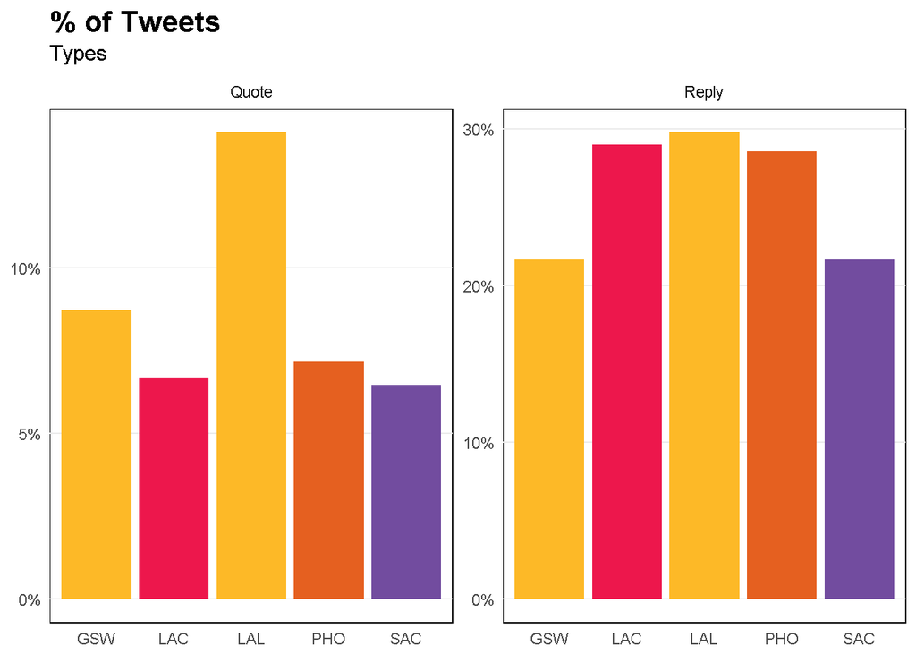

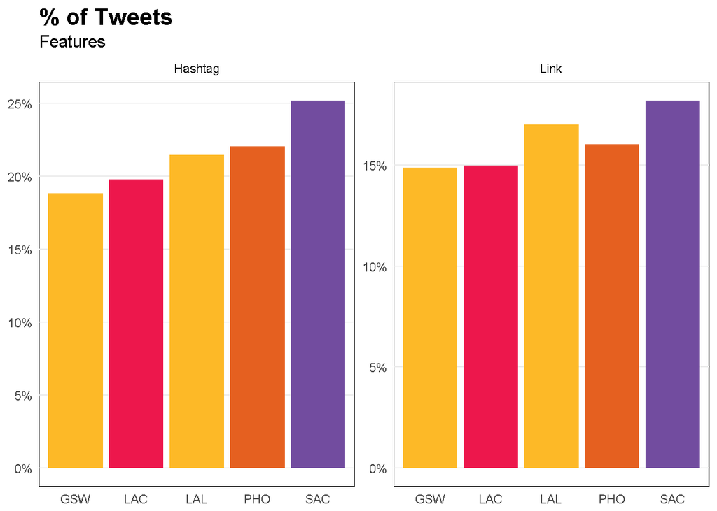

# Tweet Content

How long are the tweets?

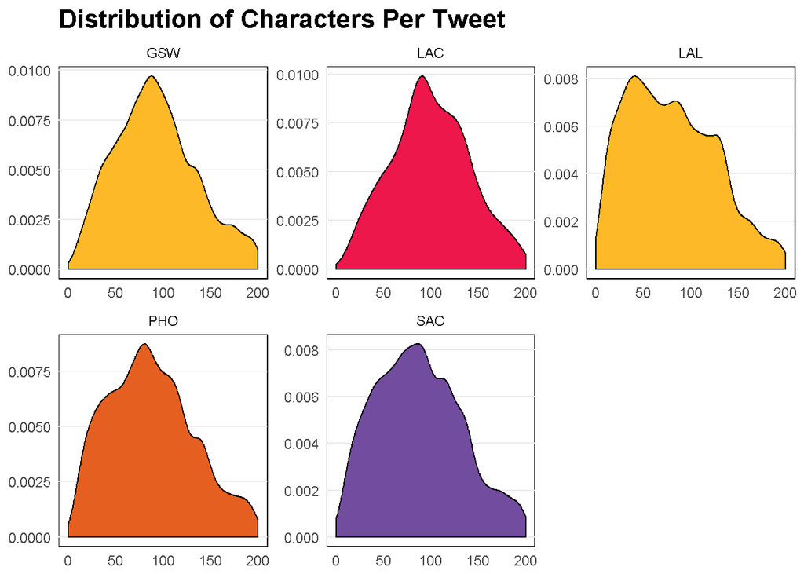

## Word Frequency and Usage

Which words are used most frequently?

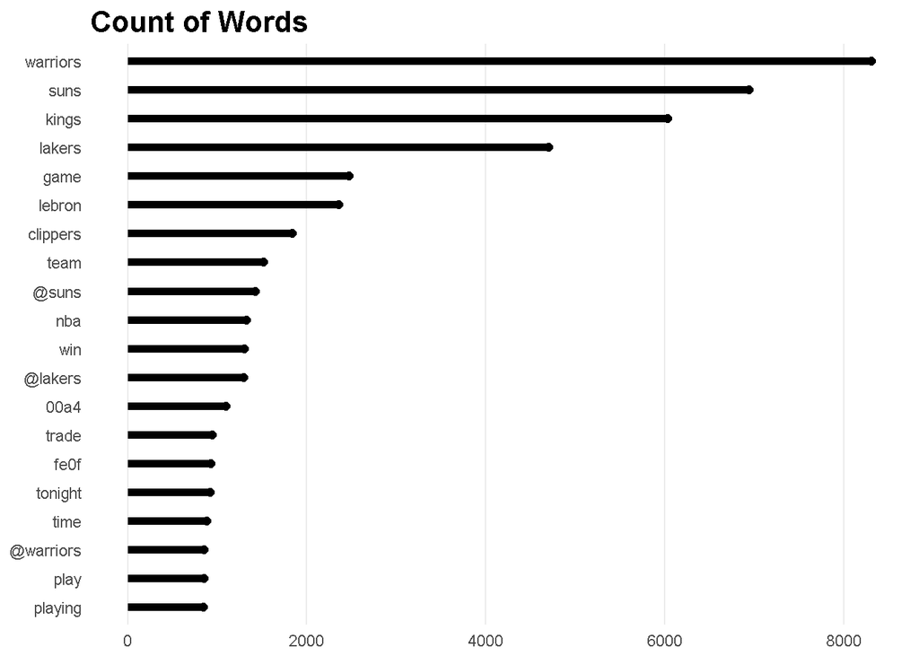

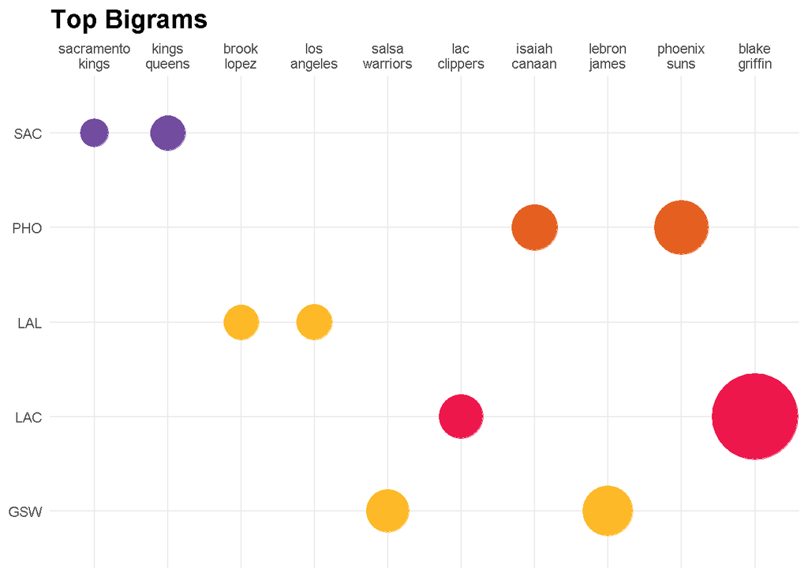

# A tibble: 10 x 6

name bigram n total freq rank 1 GSW “lebron” 472 34109 0.01384 1 2 GSW “salsa” 344 34109 0.01009 2 3 LAC “blake” 365 8732 0.04180 1 4 LAC “lac” 93 8732 0.01065 2 5 LAL “los” 168 23724 0.007081 1 6 LAL “brook” 161 23724 0.006786 2 7 PHO “phoenix” 616 37797 0.01630 1 8 PHO “isaiah” 442 37797 0.01169 2 9 SAC “kings” 188 27820 0.006758 1 10 SAC “sacramento” 124 27820 0.004457 2

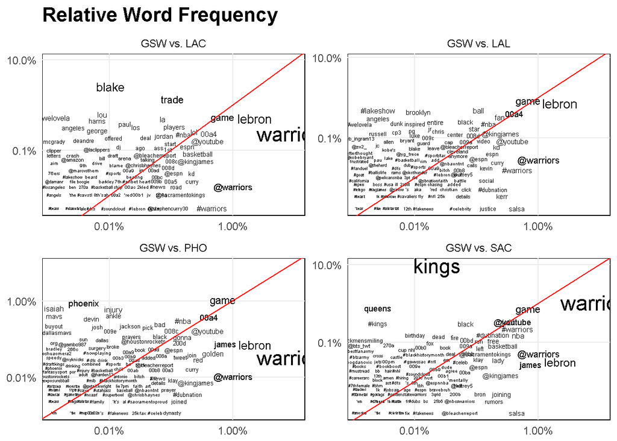

Which words are most likely to be used by one name compared to the other?

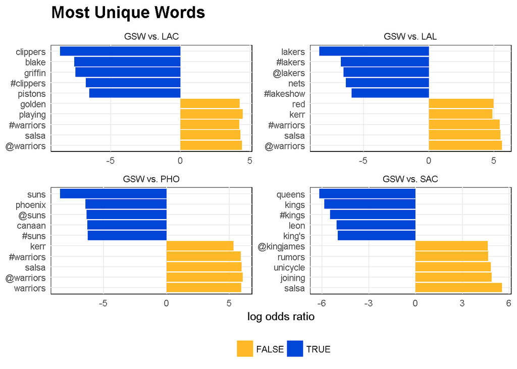

# Sentiment Analysis

What is the sentiment (i.e. “tone”) of the tweets?

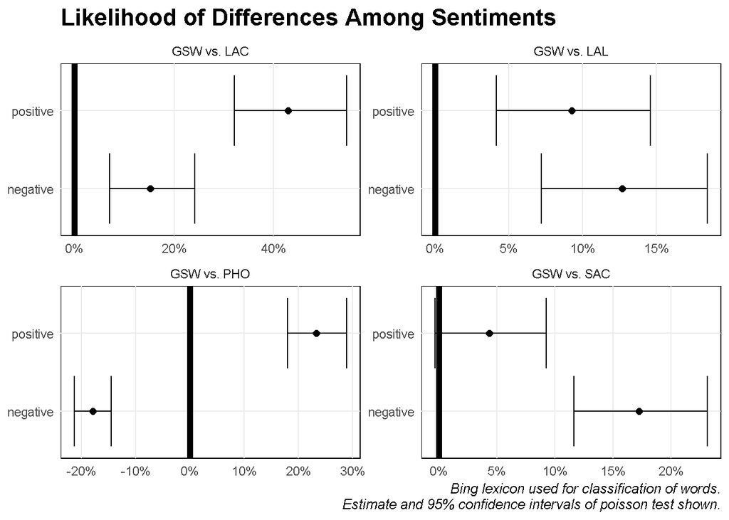

[figure not shown]

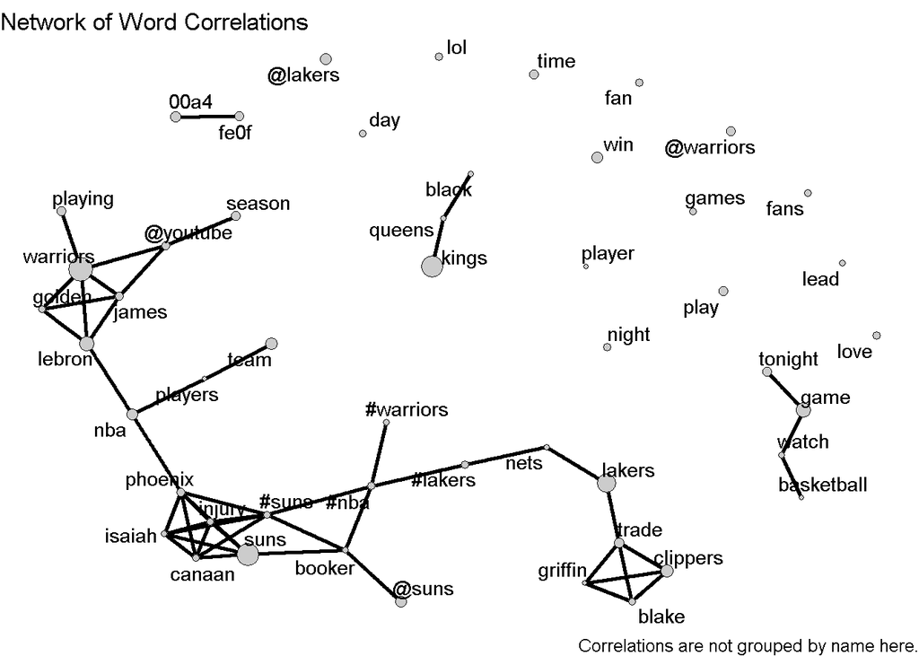